# IPL_blog

### IPL Data Analysis Using Python

#### Hello pythos, I am here to do basic python data exploration using IPL Dataset. Here, the data is from the Year 2008 to 2017. So, Lets get started

#### Cricket is one of the popular game in India. After the Start of IPL, Indian cricket standards reached an ultimate level and many talented players got a chance to prove themselves in a platform like IPL where many international cricketers join co-ordinally to play together. IPL is the one of the leading cricket tournament in the world.So, i am here to describe the IPL analysis using Python Program.

### Loading the Libraries

Pandas is used for Data Processing and is also the most popular library in python used for data analysis .

```python
import pandas as pd
```

### First we have to check whether the file is present in specified directory or not

```python
%pwd    # To check whether the file located in the present directory or not
```

```
'C:\\Users\\nsidd\\OneDrive\\Documents'
```

### To change the directory we use %cd

```python
%cd C:\Users\nsidd\OneDrive\Desktop\Python Datasets\New folder
```

```
C:\Users\nsidd\OneDrive\Desktop\Python Datasets\New folder
```

```python
%pwd
```

```
'C:\\Users\\nsidd\\OneDrive\\Desktop\\Python Datasets\\New folder'
```

### Reading the Input dataset and name it as your wish. I assumed it has df

```python
df=pd.read_csv('Match.csv',sep=",")
```

```python
df.head()   # to print the first 5 rows and also to check whether we have taken the correct dataset
```

|  | Match_SK | match_id | Team1 | Team2 | match_date | Season_Year | Venue_Name | City_Name | Country_Name | Toss_Winner | match_winner | Toss_Name | Win_Type | Outcome_Type | ManOfMach | Win_Margin | Country_id |
| --- | --- | --- | --- | --- | --- | --- | --- | --- | --- | --- | --- | --- | --- | --- | --- | --- | --- |
| 0 | 0 | 335987 | Royal Challengers Bangalore | Kolkata Knight Riders | 4/18/2008 | 2008 | M Chinnaswamy Stadium | Bangalore | India | Royal Challengers Bangalore | Kolkata Knight Riders | field | runs | Result | BB McCullum | 140.0 | 1 |
| 1 | 1 | 335988 | Kings XI Punjab | Chennai Super Kings | 4/19/2008 | 2008 | Punjab Cricket Association Stadium, Mohali | Chandigarh | India | Chennai Super Kings | Chennai Super Kings | bat | runs | Result | MEK Hussey | 33.0 | 1 |
| 2 | 2 | 335989 | Delhi Daredevils | Rajasthan Royals | 4/19/2008 | 2008 | Feroz Shah Kotla | Delhi | India | Rajasthan Royals | Delhi Daredevils | bat | wickets | Result | MF Maharoof | 9.0 | 1 |
| 3 | 3 | 335990 | Mumbai Indians | Royal Challengers Bangalore | 4/20/2008 | 2008 | Wankhede Stadium | Mumbai | India | Mumbai Indians | Royal Challengers Bangalore | bat | wickets | Result | MV Boucher | 5.0 | 1 |
| 4 | 4 | 335991 | Kolkata Knight Riders | Deccan Chargers | 4/20/2008 | 2008 | Eden Gardens | Kolkata | India | Deccan Chargers | Kolkata Knight Riders | bat | wickets | Result | DJ Hussey | 5.0 | 1 |

### Getting Basic Details of Data

Shape gives the number of rows and columns in the data. Here, 637 rows and 17 columns are present.

```python
df.shape  # Shape represents the number of rows and columns present in the data
```

```
(637, 17)
```

### Different types of data present in the dataset?

```python
df.info()
```

```
<class 'pandas.core.frame.DataFrame'>
RangeIndex: 637 entries, 0 to 636
Data columns (total 17 columns):
Match_SK        637 non-null int64
match_id        637 non-null int64
Team1           637 non-null object
Team2           637 non-null object
match_date      637 non-null object
Season_Year     637 non-null int64
Venue_Name      636 non-null object
City_Name       637 non-null object
Country_Name    637 non-null object
Toss_Winner     636 non-null object
match_winner    634 non-null object
Toss_Name       636 non-null object
Win_Type        635 non-null object
Outcome_Type    637 non-null object
ManOfMach       633 non-null object
Win_Margin      628 non-null float64
Country_id      637 non-null int64
dtypes: float64(1), int64(4), object(12)
memory usage: 84.7+ KB
```

##### These are the different types of data present in the dataset like Integer,Float,Object/String

### Lets get into more details of the data

```python
df.describe()
```

|  | Match_SK | match_id | Season_Year | Win_Margin | Country_id |
| --- | --- | --- | --- | --- | --- |
| count | 637.000000 | 6.370000e+02 | 637.000000 | 628.000000 | 637.000000 |
| mean | 318.000000 | 6.378825e+05 | 2012.497645 | 17.272293 | 1.152276 |
| std | 184.030342 | 2.356312e+05 | 2.776600 | 22.212632 | 0.438388 |
| min | 0.000000 | 3.359870e+05 | 2008.000000 | 0.000000 | 1.000000 |
| 25% | 159.000000 | 4.191550e+05 | 2010.000000 | 6.000000 | 1.000000 |
| 50% | 318.000000 | 5.483830e+05 | 2012.000000 | 8.000000 | 1.000000 |
| 75% | 477.000000 | 8.297480e+05 | 2015.000000 | 20.000000 | 1.000000 |
| max | 636.000000 | 1.082650e+06 | 2017.000000 | 146.000000 | 3.000000 |

#### This describes the basic statistics of the data like mean, standard deviation, minimum,maximum,1st quartile,2nd quartile,3rd quartile etc

#### Number of matches played in each season?

```python
df['Season_Year'].value_counts()
```

```
2013    76
2012    74
2011    73
2017    60
2016    60
2014    60
2010    60
2015    59
2008    58
2009    57
Name: Season_Year, dtype: int64
```

#### From the above syntax we can get the number of counts/matches played in each season using value_counts. The maximum matches played is in the year 2013 because there are 9 teams participated in this year.The least number of matches palyed is 57 in the year 2009.

### Number of matches played in each venue?

```python
df['Venue_Name'].value_counts()
```

```
M Chinnaswamy Stadium                                   66
Eden Gardens                                            61
Feroz Shah Kotla                                        60
Wankhede Stadium                                        57
MA Chidambaram Stadium, Chepauk                         48
Rajiv Gandhi International Stadium, Uppal               41
Punjab Cricket Association Stadium, Mohali              35
Sawai Mansingh Stadium                                  33
Dr DY Patil Sports Academy                              17
Subrata Roy Sahara Stadium                              17
Maharashtra Cricket Association Stadium                 15
Kingsmead                                               15
SuperSport Park                                         12
Sardar Patel Stadium, Motera                            12
Dr. Y.S. Rajasekhara Reddy ACA-VDCA Cricket Stadium     11
Brabourne Stadium                                       11
Saurashtra Cricket Association Stadium                  10
Himachal Pradesh Cricket Association Stadium             9
Rajiv Gandhi International Stadium Uppal                 8
New Wanderers Stadium                                    8
Newlands                                                 7
Punjab Cricket Association IS Bindra Stadium, Mohali     7
St George's Park                                         7
Barabati Stadium                                         7
JSCA International Stadium Complex                       7
Sheikh Zayed Stadium                                     7
Dubai International Cricket Stadium                      7
Shaheed Veer Narayan Singh International Stadium         6
Sharjah Cricket Stadium                                  6
Nehru Stadium                                            5
Holkar Cricket Stadium                                   5
Green Park                                               4
Punjab Cricket Association IS Bindra Stadium Mohali      4
Vidarbha Cricket Association Stadium, Jamtha             3
Buffalo Park                                             3
De Beers Diamond Oval                                    3
OUTsurance Oval                                          2
Name: Venue_Name, dtype: int64
```

#### From the above syntax we can find the Number of matches played in each Venue.The maximum matches played in a particular venue is M chinnaswamy Stadium In Bengaluru.

#### Match Winners based on Season Year?

```python
df.groupby('Season_Year')['match_winner'].value_counts()
```

```
Season_Year  match_winner
2008         Rajasthan Royals               13
             Kings XI Punjab                10
             Chennai Super Kings             9
             Delhi Daredevils                7
             Mumbai Indians                  7
             Kolkata Knight Riders           6
             Royal Challengers Bangalore     4
             Deccan Chargers                 2
2009         Delhi Daredevils               10
             Deccan Chargers                 9
             Royal Challengers Bangalore     9
             Chennai Super Kings             8
             Kings XI Punjab                 7
             Rajasthan Royals                6
             Mumbai Indians                  5
             Kolkata Knight Riders           3
2010         Mumbai Indians                 11
             Chennai Super Kings             9
             Deccan Chargers                 8
             Royal Challengers Bangalore     8
             Delhi Daredevils                7
             Kolkata Knight Riders           7
             Rajasthan Royals                6
             Kings XI Punjab                 4
2011         Chennai Super Kings            11
             Mumbai Indians                 10
             Royal Challengers Bangalore    10
             Kolkata Knight Riders           8
             Kings XI Punjab                 7
             Deccan Chargers                 6
                                            ..
2014         Rajasthan Royals                7
             Sunrisers Hyderabad             6
             Royal Challengers Bangalore     5
             Delhi Daredevils                2
2015         Chennai Super Kings            10
             Mumbai Indians                 10
             Royal Challengers Bangalore     8
             Kolkata Knight Riders           7
```

[output cut: 8 more lines]

```
             Delhi Daredevils                7
             Mumbai Indians                  7
             Rising Pune Supergiants         5
             Kings XI Punjab                 4
2017         Mumbai Indians                 11
             Rising Pune Supergiants        10
             Kolkata Knight Riders           9
             Sunrisers Hyderabad             8
             Kings XI Punjab                 7
             Delhi Daredevils                6
             Gujarat Lions                   4
             Royal Challengers Bangalore     3
             abandoned                       1
             tied                            1
Name: match_winner, Length: 86, dtype: int64
```

```python
df.groupby('Season_Year')['match_winner'].value_counts().max()
```

```
13
```

#### Using groupby function we can split the data into groups based on some criteria.Here, we can see that the no.of matches won by the team based on the season.From, above syntax we can see that the maximum matches won by the Team amongst all the seasons is rajasthan royals and the record is still pending.(data is from 2008 to 2017, As far as now MI is leading match winners amongst all the seasons)

### Exploring with Dates,Months,Years

#### From Match date we want to extract the dates,month,years so we use pandas datetime to do this

```python
df['match_date']=pd.to_datetime(df['match_date'],errors='coerce')
```

#### Here, to extract month from match_date we use the below syntax to extract the month

```python
df['month']=df['match_date'].dt.month
```

#### Checking whether we got the correct month or not

```python
df['month'].head()
```

```
0    4
1    4
2    4
3    4
4    4
Name: month, dtype: int64
```

#### we use below syntax for extracting the Year

```python
df['year']=df['match_date'].dt.year
```

```python
df['year']
```

```
0      2008
1      2008
2      2008
3      2008
4      2008
5      2008
6      2008
7      2008
8      2008
9      2008
10     2008
11     2008
12     2008
13     2008
14     2008
```

[output cut: 47 more lines]

#### The below code resembles the no.of incidents where the team chosen to bat or field

```python
df['Toss_Name'].value_counts()
```

```
field    315
bat      262
Field     48
Bat       11
Name: Toss_Name, dtype: int64
```

#### From above result, we can say that teams prefer to field first rather than batting first.As it is T20 many teams prefer to chase the targets.

#### How Many Man of the Matches the players are awarded amongst all the seasons?

```python
df['ManOfMach'].value_counts()
```

```
CH Gayle            18
YK Pathan           16
DA Warner           15
AB de Villiers      15
SK Raina            14
RG Sharma           14
MS Dhoni            13
G Gambhir           13
AM Rahane           12
MEK Hussey          12
V Sehwag            11
V Kohli             11
DR Smith            11
JH Kallis           10
SR Watson           10
KA Pollard           9
A Mishra             9
SE Marsh             9
SR Tendulkar         8
RV Uthappa           7
AC Gilchrist         7
RA Jadeja            7
AT Rayudu            7
M Vijay              6
Harbhajan Singh      6
A Nehra              6
UT Yadav             6
BJ Hodge             6
AD Russell           6
KC Sangakkara        5
                    ..
Narine               1
MS Gony              1
AP Tare              1
Wasington Sundar     1
BA Bhatt             1
Mohammed Shami       1
J Botha              1
S Nadeem             1
Z Khan               1
WPUJC Vaas           1
EJG Morgan           1
KMDN Kulasekara      1
RS Bopara            1
HH Gibbs             1
KK Cooper            1
DP Nannes            1
TA Boult             1
AD Mascarenhas       1
GD McGrath           1
DL Vettori           1
R Ashwin             1
A Singh              1
YS Chahal            1
RE Levi              1
AD Mathews           1
SM Katich            1
RP Singh             1
MN Samuels           1
MA Agarwal           1
S Anirudha           1
Name: ManOfMach, Length: 202, dtype: int64
```

###### Chris Gayle Tops the List with 18 MOM amongst all the players from the above data.(as this is the old data but also Chris Gayle tops the list with 21 Moms(2019)). No better Example to show that how Destructive Batsman "Christopher Henry Gayle" is.

#### Most Number of matches held in a city?

```python
df['City_Name'].value_counts()
```

```
Mumbai                85
Kolkata               61
Delhi                 60
Bangalore             58
Chennai               48
Chandigarh            42
Hyderabad             41
Jaipur                33
Pune                  32
Abu Dhabi             20
Durban                15
Centurion             12
Ahmedabad             12
Visakhapatnam         11
Rajkot                10
Bengaluru              9
Dharamsala             9
Johannesburg           8
Hyderabad (Deccan)     8
Ranchi                 7
Cape Town              7
Cuttack                7
Port Elizabeth         7
Raipur                 6
Kochi                  5
Indore                 5
Kanpur                 4
Mohali                 4
East London            3
Kimberley              3
Nagpur                 3
Bloemfontein           2
Name: City_Name, dtype: int64
```

#### Lets See Some Visualizations using Python

###### At First we have to import Matplotlib library. It is most widely used library for data visualization.We can create various plots like scattered plot,bar plot, box plot, etc using this library.

```python
import matplotlib.pyplot as plt
```

### How many matches are played in each season of IPL(2008 to 2017)?

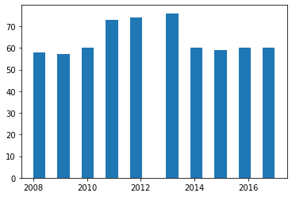

```python
plt.hist(df['Season_Year'],bins=20)      # Using Histogram to plot these data
```

```python
import seaborn as sns
```

#### Lets See Some More Visualizations

### Most No.of Matches Played in Each Season?

[figure not shown]

```python
sns.countplot(x='Season_Year',data=df)
```

##### We can see that from 2011 to 2013 no.of matches played shows increasing trend whereas 2013 tops the list with most no.of matches played around 76.

### Which team is Most successful among all the seasons?

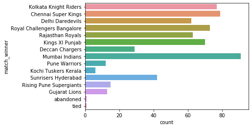

```python
sns.countplot(y='match_winner',data=df)
```

##### By using countplot we can check the count of match_winner for finding successful team among all the seasons. Mumbai Indians is the most successful team from 2008 to 2017. (As per latest reports, MI is the most successful team because it has 4 IPL titles and also having a huge fan base, "Proud to be a MI Fan :) "). CSK is the second most successful team after MI.

#### "Just a beginning plenty to come",Stay Tuned for Some more Data Analysis using Python.